# CPLN 675 Midterm: Floods

Lechuan Huang

Zihan Zhao

2022-03-29

## Motivation

In recent years, heavy rainfall and resulting flooding caused severe damage across Canada, particularly on the west coast. But a new report suggests that rising sea levels due to climate change put Canadians at greater risk of flooding. Disasters caused by flooding are the primary cause of economic losses in eastern Canada.

A recently released flood-related report found that nearly 4.8 million Canadians live within 10 kilometers of the eastern or western coastline and are “likely to be disproportionately affected by climate change-induced flooding,” including rising sea levels, extreme weather events, or changing tidal events.

To minimize the negative impact of flooding on cities in western Canada, we need a new model that effectively predicts flood risk. By summarizing and analyzing the flood forecasting model in eastern cities, we can provide the government with a range of crucial placement areas in the urban area that is more affected by floods. Relevant government departments can also make urban emergency plans before extreme weather and other disasters to reduce disaster costs.

Our goal is to build a flood prediction regression model by collecting and integrating various urban resource data from the Open data websites of the two cities to predict the high-risk areas of flood disasters in future cities. Furthermore, we hope this forecast report will provide helpful suggestions for urban flood control emergency plans and have specific guiding significance for the future urban design of relevant municipal departments and planners.

This model analysis method can comprehensively consider and integrate the current status of various aspects of the city (such as hydrological resources, land use, elevation) and is more comprehensive than other prediction methods. Therefore, the prediction results of this model are more reliable when the dependent variable is properly screened. Because the prediction model will predict the high-risk areas of future flood disasters in the city, it is very instructive for future urban plots’ rezoning and proposed land use. This prediction also helps planners design building density and structural stability more rationally.

## Data

Load the packages

```r
  library(caret)
  library(FNN)
  library(pscl)
  library(plotROC)
  library(pROC)
  library(sf)
  library(dplyr)
  library(tidyverse)
  library(knitr)
  library(kableExtra)
  library(tigris)
  library(viridis)
  library(raster)

  root.dir = "https://raw.githubusercontent.com/urbanSpatial/Public-Policy-Analytics-Landing/master/DATA/"
  source("https://raw.githubusercontent.com/urbanSpatial/Public-Policy-Analytics-Landing/master/functions.r")
```

We bring various dependent variables into the predictor generated by mapping the prediction model through R. We then compare the high-risk areas of flooding in the generated prediction map with the maps of flooded areas in previous years and the existing urban hydrological map. If our prediction map has a high degree of coincidence with these two maps, our prediction model is more accurate and effective.

Here we load the relevant raw data required for this study: the Calgary boundary, hydrological information and historical flood data.

```r
#calgary boundary data
boundary <- st_read("C:/Users/mnxan/OneDrive/Documents/CPLN 675/midTermProject_Data/CALGIS_CITYBOUND_LIMIT")%>%
  st_transform(3780)

#calgary river data
hydro <- st_read("C:/Users/mnxan/OneDrive/Documents/CPLN 675/midTermProject_Data/calgary_data/river/geo_export_ab7cc7e1-3e76-4c40-b170-9463a9b09aa0.shp")%>%
  st_transform(3780)%>%
  filter(., feature_ty=="water course")%>%
  dplyr::select(feature_ty,geometry)

#calgary flood data
flood <- st_read("https://data.calgary.ca/resource/tp6q-x2v7.geojson")%>%
  st_transform(3780)
```

Then we convert the boundary data into fishnet.

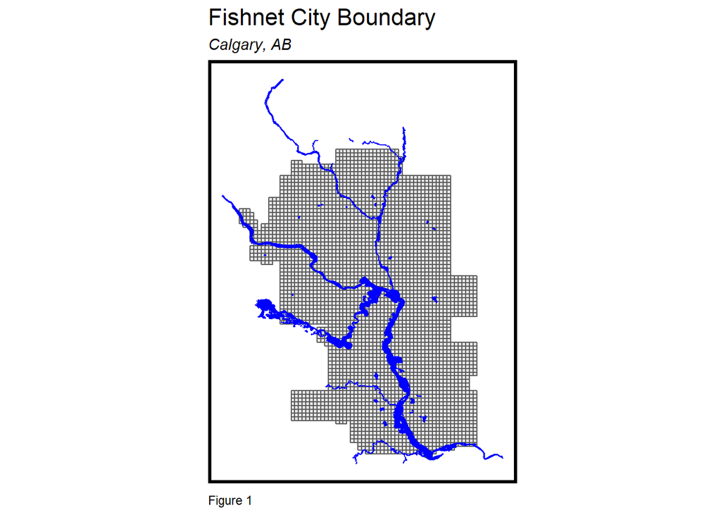

```r
#make calgary boundary into fishned
fishnet <-
  st_make_grid(boundary,
               cellsize = 500,
               square = TRUE) %>%
  .[boundary] %>%            # <- MDH Added
  st_sf() %>%
  mutate(uniqueID = rownames(.))

ggplot() +
  geom_sf(data=fishnet) +
  geom_sf(data=flood, color = "blue", fill = "blue") +
  labs(title="Fishnet City Boundary",
       subtitle="Calgary, AB",
       caption="Figure 1") +
  mapTheme()
```

### Exploratory Analysis

Here we import the slope raster generated by Calgary’s DEM data, and we found out that the area with steep slope (> 10 degrees) seems to be correlated to inundation map.

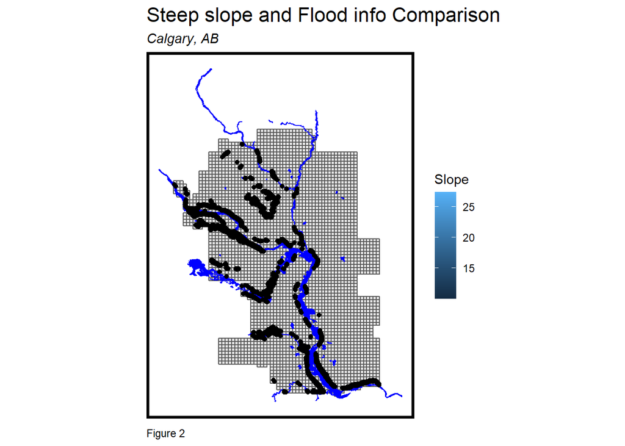

```r
sloper <- raster("C:/Users/mnxan/OneDrive/Documents/CPLN 675/midTermProject_Data/Midterm/Export/Slope.tif")

slopep <-
  rasterToPoints(sloper) %>%
  as.data.frame() %>%
  st_as_sf(coords = c("x", "y"), crs = 3780)

steepp <- slopep %>%
  filter(Slope > 10)

slopep_net <-
  slopep %>%
  aggregate(., fishnet, mean)%>%
  mutate(sloper = ifelse(is.na(Slope), mean(na.omit(Slope)), Slope))

steep_net <-
  steepp %>%
  mutate(steep =1) %>%
  aggregate(., fishnet, sum) %>%
  mutate(steep = ifelse(is.na(steep), 0, steep))%>%
  dplyr::select(steep)


ggplot() +
  geom_sf(data=fishnet) +
  geom_sf(data=flood, color = "blue", fill = "blue") +
  geom_sf(data=steepp, aes(fill=Slope)) +
  labs(title="Steep slope and Flood info Comparison",
       subtitle="Calgary, AB",
       caption="Figure 2") +
  mapTheme()
```

Then we import the DEM data. We assume places with low altitude as higher probability of being flooded.

```r
elevation <- raster("C:/Users/mnxan/OneDrive/Documents/CPLN 675/midTermProject_Data/calgary_data/elevation_dem/cal_dem_ele.tif")

elevationp <-
  rasterToPoints(elevation) %>%
  as.data.frame() %>%
  st_as_sf(coords = c("x", "y"), crs = 3780)

#the 15% lowest
quantile(elevationp$cal_dem_ele, probs = 0.15)
```

```
##  15%
## 1034
```

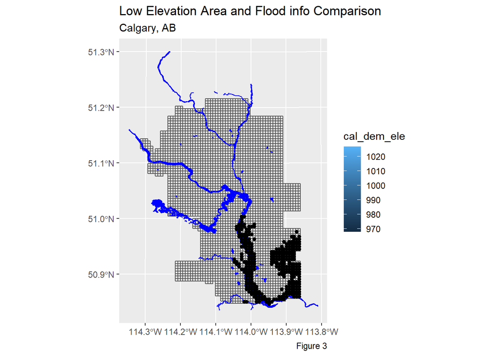

```r
lowland <- elevationp%>%
  filter(cal_dem_ele <1028)

elevation_net <-
  elevationp %>%
  aggregate(., fishnet, mean)%>%
  mutate(elevation = ifelse(is.na(cal_dem_ele), mean(na.omit(cal_dem_ele)), cal_dem_ele))

elevation_net$cal_dem_ele[is.na(elevation_net$cal_dem_ele)] = mean(na.omit(elevation_net$cal_dem_ele))

ggplot() +
  geom_sf(data=fishnet) +
  geom_sf(data=flood, color = "blue", fill = "blue") +
  geom_sf(data=lowland, aes(fill=cal_dem_ele)) +
  labs(title="Low Elevation Area and Flood info Comparison",
       subtitle="Calgary, AB",
       caption="Figure 3")
```

Land-use is certainly another biggest issue. However, it’s counter-intuitive that the impervious surface does not seem to be correlated with the flood.

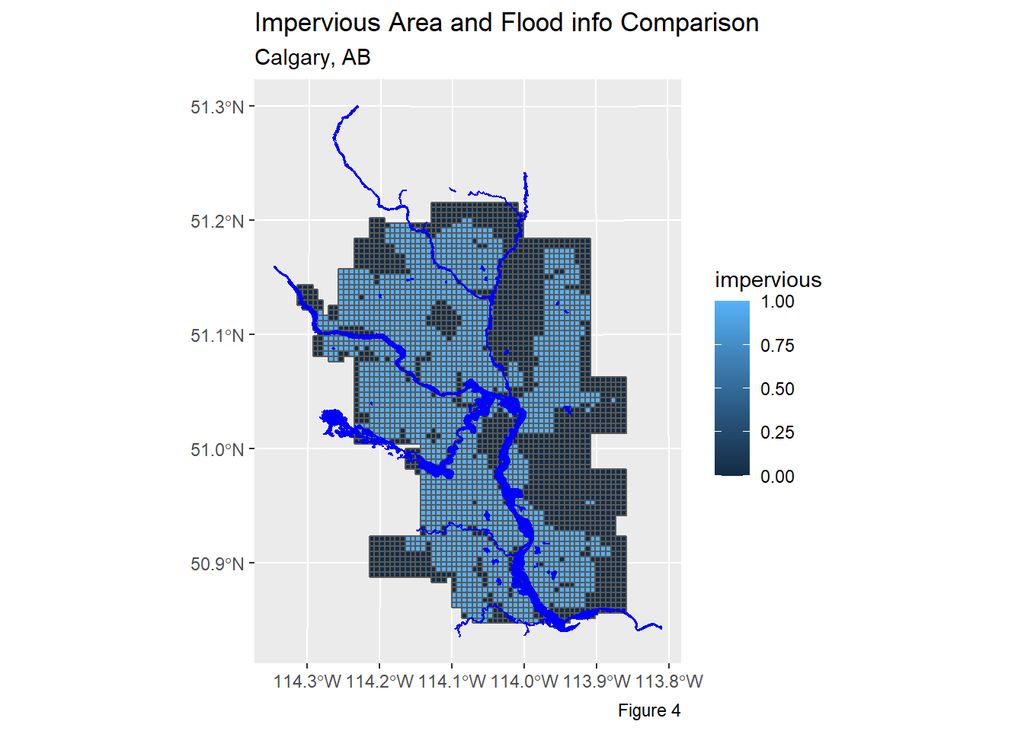

```r
landuse <- st_read("C:/Users/mnxan/OneDrive/Documents/CPLN 675/midTermProject_Data/calgary_data/landuse2/geo_export_a01cda40-3391-4b56-8667-b789489f0a99.shp")%>%
  st_transform(3780)

impervious <-
  landuse %>%
  filter(generalize== "High Rise Office and Mixed Use"|generalize == "Low Density Residential") %>%
  mutate(impervious =1) %>%
  aggregate(., fishnet, mean) %>%
  mutate(pervious = ifelse(is.na(impervious), 0, impervious))%>%
  dplyr::select(impervious)

impervious$impervious[is.na(impervious$impervious)] = 0

ggplot() +
  geom_sf(data=impervious, aes(fill=impervious)) +
  geom_sf(data=flood, color = "blue", fill = "blue")+
  labs(title="Impervious Area and Flood info Comparison",
       subtitle="Calgary, AB",
       caption="Figure 4")
```

Instead, we found out that landuse of “parks” seems to be correlated.

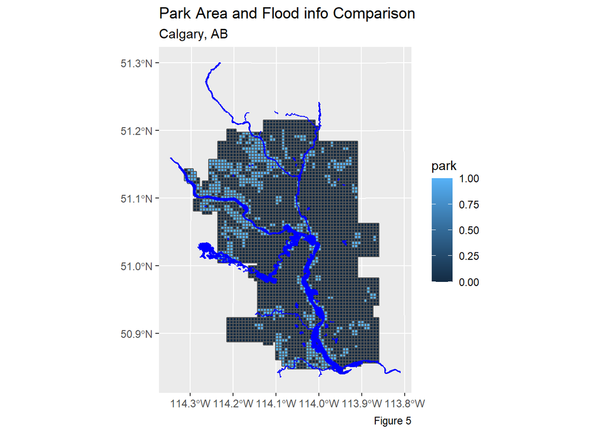

```r
park <-
  landuse %>%
  filter(generalize== "Urban Nature") %>%
  mutate(park =1) %>%
  aggregate(., fishnet, mean) %>%
  mutate(pervious = ifelse(is.na(park), 0, park))%>%
  dplyr::select(park)

park$park[is.na(park$park)] = 0

ggplot() +
  geom_sf(data=park, aes(fill=park)) +
  geom_sf(data=flood, color = "blue", fill = "blue")+
  labs(title="Park Area and Flood info Comparison",
       subtitle="Calgary, AB",
       caption="Figure 5")
```

Similarly, tree data seems to work.

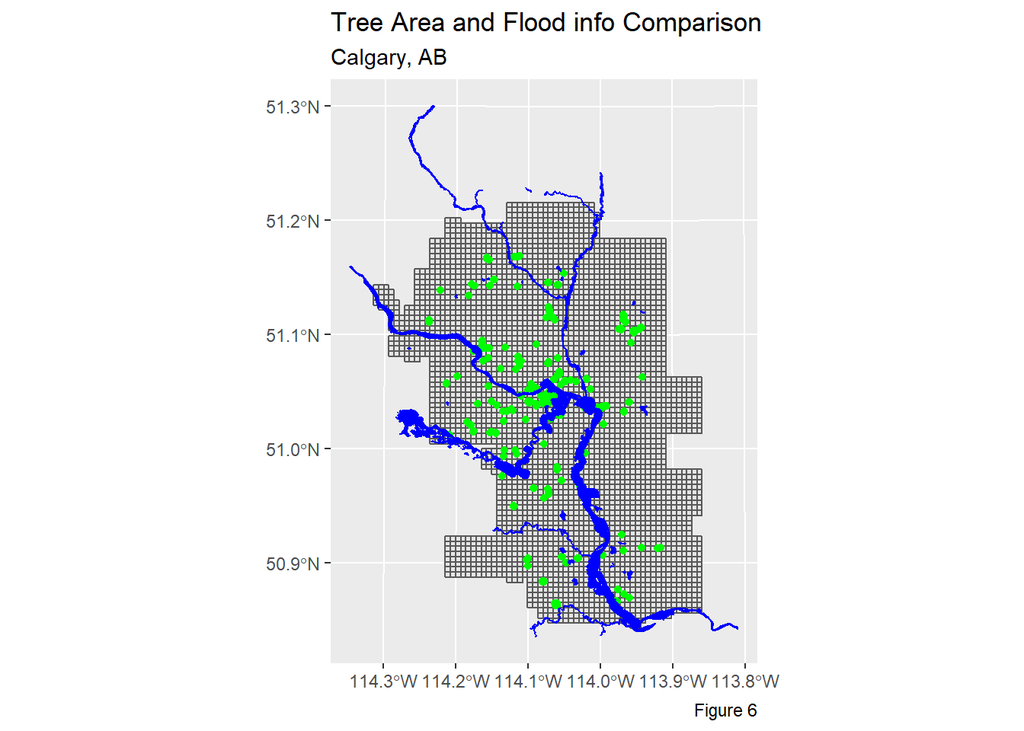

```r
tree <- st_read("https://data.calgary.ca/resource/tfs4-3wwa.geojson") %>%
  st_transform(crs=3780)

tree_net<-
  tree %>%
  mutate(tree = 1) %>%
  dplyr::select(tree)%>%
  aggregate(., fishnet, sum) %>%
  mutate(tree = ifelse(is.na(tree), 0, tree))

ggplot() +
  geom_sf(data=fishnet) +
  geom_sf(data=tree, color = "green", fill = "green")+
  geom_sf(data=flood, color = "blue", fill = "blue")+
  labs(title="Tree Area and Flood info Comparison",
       subtitle="Calgary, AB",
       caption="Figure 6")
```

### Join to the fishnet

We join our predictors into the fishnet. In addition to join the raw data into the fishnet, we also calculate the distance of fishnet block to another related fishnet block.

```r
vars_net <-
  cbind(elevation_net, tree_net, slopep_net, steep_net, park)%>%
  mutate(slope=sloper)%>%
  dplyr::select(elevation, tree, slope, steep, park, -cal_dem_ele)%>%
  mutate(uniqueID = rownames(.))

nn_function <- function(measureFrom,measureTo,k) {
  measureFrom_Matrix <-
    as.matrix(measureFrom)
  measureTo_Matrix <-
    as.matrix(measureTo)
  nn <-
    get.knnx(measureTo, measureFrom, k)$nn.dist
  output <-
    as.data.frame(nn) %>%
    rownames_to_column(var = "thisPoint") %>%
    gather(points, point_distance, V1:ncol(.)) %>%
    arrange(as.numeric(thisPoint)) %>%
    group_by(thisPoint) %>%
    summarize(pointDistance = mean(point_distance)) %>%
    arrange(as.numeric(thisPoint)) %>%
    dplyr::select(-thisPoint) %>%
    pull()

  return(output)
}

vars_net$steep.nn =
  nn_function(st_coordinates(st_centroid(vars_net)), st_coordinates(steepp), 3)

vars_net$tree.nn =
  nn_function(st_coordinates(st_centroid(vars_net)), st_coordinates(tree), 3)

vars_net$hydro.nn =
  nn_function(st_coordinates(st_centroid(vars_net)), st_coordinates(st_centroid(hydro)), 3)

river_net <-
  hydro %>%
  dplyr::select() %>%
  mutate(river = as.numeric(1)) %>%
  aggregate(., fishnet, mean) %>%
  mutate(river = ifelse(is.na(river), 0, river))

flood_net <-
  flood %>%
  dplyr::select() %>%
  mutate(flood = as.numeric(1)) %>%
  aggregate(., fishnet, mean) %>%
  mutate(flood = ifelse(is.na(flood), 0, flood))

final_net <-
  cbind(vars_net,flood_net)
```

## Model

Firstly, we splite our training set and testing set.

```r
final <-
  final_net %>%
  mutate(elev = elevation-min(elevation),
         stee = steep/max(steep)) %>%
  dplyr::select(-elevation, -steep,-geometry.1)%>%
  rename(floodm = flood)

set.seed(3456)
trainIndex <- createDataPartition(y = paste(final$flood), p = .70,
                                  list = FALSE,
                                  times = 1)

finalTrain <- final[ trainIndex,]
finalTest  <- final[-trainIndex,]
```

Then we build our model using Generalized linear model.

```r
finalModel <- glm(floodm ~ .,
                  family="binomial"(link="logit"), data = finalTrain %>%
                    as.data.frame() %>%
                    dplyr::select(-geometry,-uniqueID))

summary(finalModel)
```

```
##
## Call:
## glm(formula = floodm ~ ., family = binomial(link = "logit"),
##     data = finalTrain %>% as.data.frame() %>% dplyr::select(-geometry,
##         -uniqueID))
##
## Deviance Residuals:
##     Min       1Q   Median       3Q      Max
## -2.4092  -0.5182  -0.2442  -0.0595   3.7328
##
## Coefficients:
##               Estimate Std. Error z value Pr(>|z|)
## (Intercept)  1.863e+00  2.515e-01   7.404 1.32e-13 ***
## tree         1.771e-02  1.524e-02   1.162 0.245121
## slope        2.317e-01  6.686e-02   3.466 0.000528 ***
## park         1.239e+00  1.519e-01   8.152 3.59e-16 ***
## steep.nn    -5.438e-04  6.431e-05  -8.455  < 2e-16 ***
## tree.nn     -1.537e-04  6.202e-05  -2.478 0.013212 *
## hydro.nn    -2.023e-04  7.310e-05  -2.767 0.005658 **
## elev        -2.432e-02  2.065e-03 -11.778  < 2e-16 ***
## stee        -2.349e-01  1.063e+00  -0.221 0.825161
## ---
## Signif. codes:  0 '***' 0.001 '**' 0.01 '*' 0.05 '.' 0.1 ' ' 1
##
## (Dispersion parameter for binomial family taken to be 1)
##
##     Null deviance: 2280.9  on 2503  degrees of freedom
## Residual deviance: 1501.6  on 2495  degrees of freedom
## AIC: 1519.6
##
## Number of Fisher Scoring iterations: 7
```

When it’s done, we output the predicted probability of a test set fishnet cell being flooded conditional on our model.

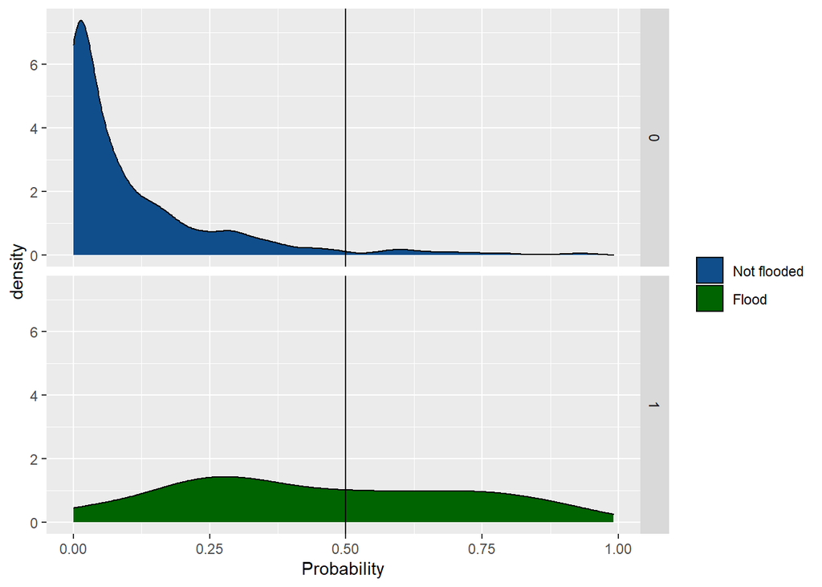

```r
classProbs <- predict(finalModel, finalTest, type="response")

testProbs <- data.frame(obs = as.numeric(finalTest$flood),
                        pred = classProbs)

ggplot(testProbs, aes(x = pred, fill=as.factor(obs))) + geom_density() +
  facet_grid(obs ~ .) + xlab("Probability") + geom_vline(xintercept = .5) +
  scale_fill_manual(values = c("dodgerblue4", "darkgreen"),
                    labels = c("Not flooded","Flood"),
                    name = "")
```

## Validation

### Statistical Validation

To test its usefulness, we firstly conduct the ROC Analysis. With the area-numder-curve (AUC) of 0.8737, indicating that it is pretty good model.

```r
testProbs$predClass  = ifelse(testProbs$pred > .5 ,1,0)

caret::confusionMatrix(reference = as.factor(testProbs$obs),
                       data = as.factor(testProbs$predClass),
                       positive = "1")
```

```
## Confusion Matrix and Statistics
##
##           Reference
## Prediction   0   1
##          0 858 104
##          1  32  77
##
##                Accuracy : 0.873
##                  95% CI : (0.8516, 0.8924)
##     No Information Rate : 0.831
##     P-Value [Acc > NIR] : 8.745e-05
##
##                   Kappa : 0.4628
##
##  Mcnemar's Test P-Value : 1.142e-09
##
##             Sensitivity : 0.4254
##             Specificity : 0.9640
##          Pos Pred Value : 0.7064
##          Neg Pred Value : 0.8919
##              Prevalence : 0.1690
##          Detection Rate : 0.0719
##    Detection Prevalence : 0.1018
##       Balanced Accuracy : 0.6947
##
##        'Positive' Class : 1
##
```

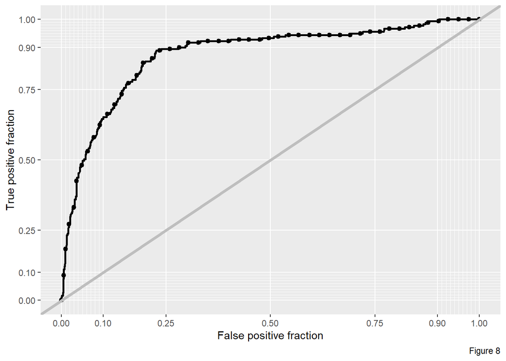

```r
ggplot(testProbs, aes(d = obs, m = pred)) +
  geom_roc(n.cuts = 50, labels = FALSE) +
  style_roc(theme = theme_grey) +
  geom_abline(slope = 1, intercept = 0, size = 1.5, color = 'grey') +
  labs(caption="Figure 8")
```

```r
auc(testProbs$obs, testProbs$pred)
```

```
## Area under the curve: 0.8737
```

We examine the goodness of fit metrics for random k-fold cross validation.

```r
ctrl <- trainControl(method = "cv",
                     number = 100,
                     savePredictions = TRUE)

cvFit <- train(as.factor(floodm) ~ ., data = finalTrain%>%
               as.data.frame()%>%
               dplyr::select(-uniqueID, -geometry),
               method="glm", family="binomial",
               trControl = ctrl)

cvFit
```

```
## Generalized Linear Model
##
## 2504 samples
##    8 predictor
##    2 classes: '0', '1'
##
## No pre-processing
## Resampling: Cross-Validated (100 fold)
## Summary of sample sizes: 2479, 2478, 2480, 2479, 2480, 2479, ...
## Resampling results:
##
##   Accuracy   Kappa
##   0.8773731  0.4672534
```

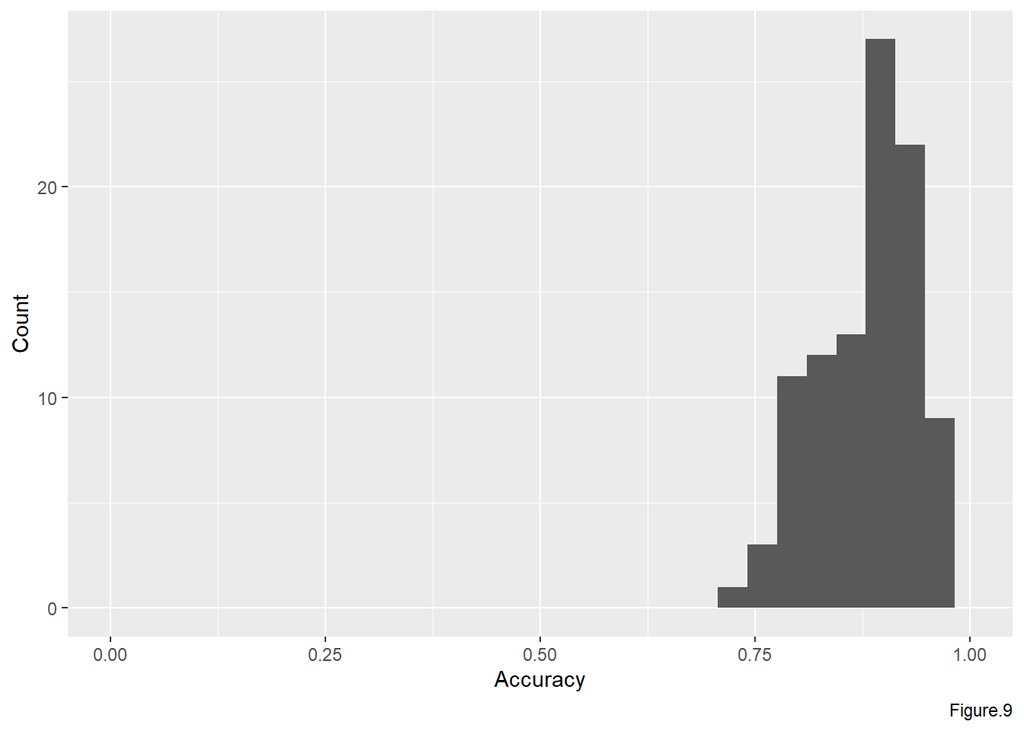

```r
ggplot(as.data.frame(cvFit$resample), aes(Accuracy)) +
  geom_histogram() +
  scale_x_continuous(limits = c(0, 1)) +
  labs(x="Accuracy",
       y="Count",
       caption = "Figure.9")
```

### Mapping the prediction

To see how well it predict, we mapped out prediction.

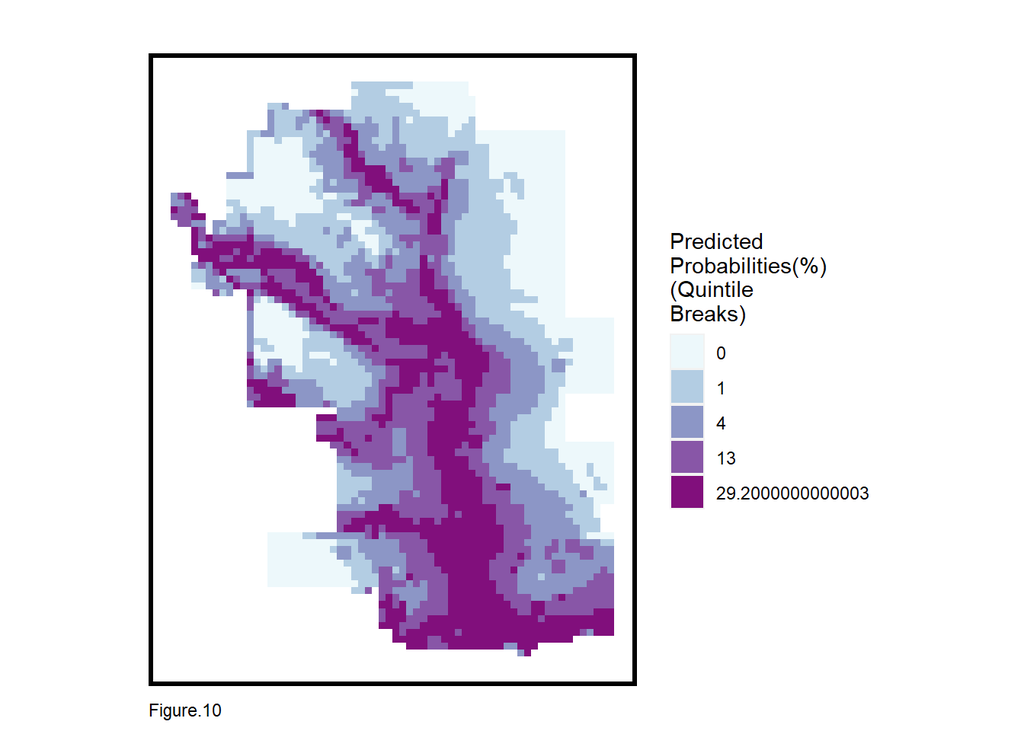

```r
allPredictions <-
  predict(cvFit, final, type="prob")[,2]

finalflood <-
  cbind(final,allPredictions) %>%
  mutate(allPredictions = round(allPredictions * 100))

ggplot() +
  geom_sf(data=finalflood, aes(fill=factor(ntile(allPredictions,5))), colour=NA) +
  scale_fill_manual(values = c("#edf8fb","#b3cde3","#8c96c6","#8856a7","#810f7c"),
                    labels=as.character(quantile(finalflood$allPredictions,
                                                 c(0.1,.2,.4,.6,.8),na.rm=T)),
                    name="Predicted\nProbabilities(%)\n(Quintile\nBreaks)") +
  mapTheme() +
  labs(title="",
       caption = "Figure.10")
```

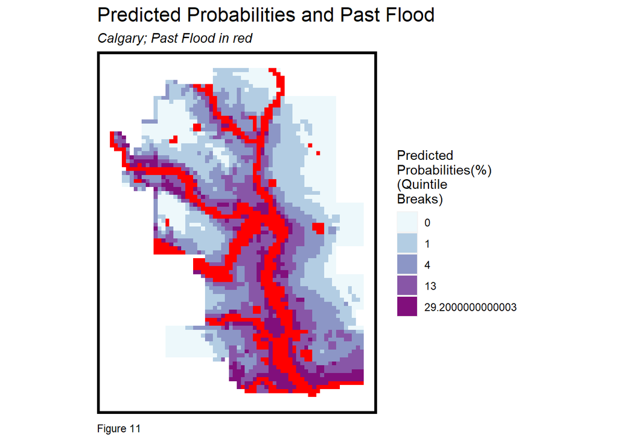

```r
ggplot() +
  geom_sf(data=finalflood, aes(fill=factor(ntile(allPredictions,5))), colour=NA) +
  scale_fill_manual(values = c("#edf8fb","#b3cde3","#8c96c6","#8856a7","#810f7c"),
                    labels=as.character(quantile(finalflood$allPredictions,
                                                 c(0.1,.2,.4,.6,.8),na.rm=T)),
                    name="Predicted\nProbabilities(%)\n(Quintile\nBreaks)") +
  geom_sf(data=finalflood %>%
            filter(floodm == 1),
          fill="red",colour=NA) +
  mapTheme() +
  labs(title="Predicted Probabilities and Past Flood",
       subtitle="Calgary; Past Flood in red",
       caption = "Figure 11")
```

To further examine the spatial generalizability of our model, we plot the confusion matrix over space (for the train set).

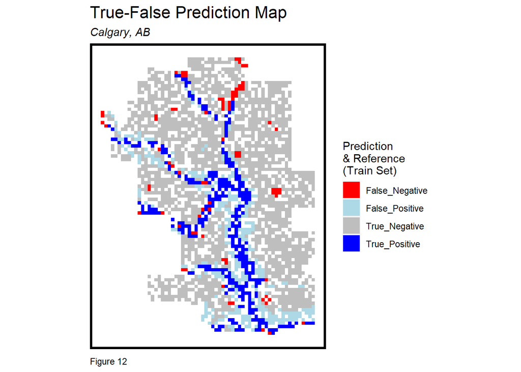

```r
trainPredictions <-
  predict(cvFit, finalTrain, type="prob")[,2]

matrix <-
  cbind(finalTrain,trainPredictions) %>%
  mutate(trainPredictions = round(trainPredictions * 100)) %>%
  mutate(pre = ifelse(trainPredictions>22,1,0)) %>%
  mutate(compare=
           ifelse(pre==0 & floodm==0,"True_Negative",
                  ifelse(pre==1 & floodm==1,"True_Positive",
                         ifelse(pre==0 & floodm==1,"False_Negative",
                                ifelse(pre==1 & floodm==0,"False_Positive",0)))))

ggplot() +
  geom_sf(data=matrix, aes(fill=factor(compare)), colour=NA) +
  scale_fill_manual(values = c("red","lightblue","grey","blue"),
                    labels= c("False_Negative","False_Positive","True_Negative","True_Positive"),
                    name="Prediction\n& Reference\n(Train Set)") +
  labs(title="True-False Prediction Map",
       subtitle="Calgary, AB",
       caption="Figure 12") +
  mapTheme()
```

Then here is the final map of prediction.

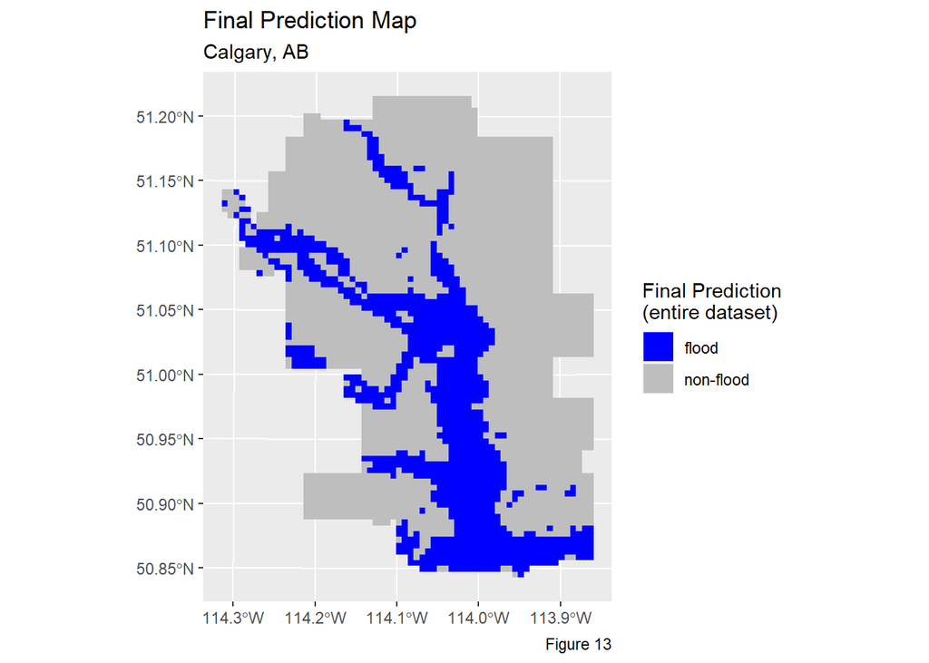

```r
finalpre <-
  finalflood %>%
  mutate(pre = ifelse(allPredictions<22,1,0))

ggplot() +
  geom_sf(data=finalpre, aes(fill=factor(pre)), colour=NA) +
  scale_fill_manual(values = c("blue","grey"),
                    labels=c("flood","non-flood"),
                    name="Final Prediction\n(entire dataset)") +
  labs(title="Final Prediction Map",
       subtitle="Calgary, AB",
       caption="Figure 13")
```

```r
  mapTheme()
```

## Comparable City

For comparison city, we choose the City of Edmonton, which is also in the Province of Alberta, Canada.

### Data

Import the City boundary data, fishnet, hydrology data and DEM data of Edmonton.

```r
ed_limit <-
  st_read("C:/Users/mnxan/OneDrive/Documents/CPLN 675/midTermProject_Data/assignment3_Edmonton/City of Edmonton - Corporate Boundary (current)/geo_export_1a08ea5f-b5bb-4ee1-9878-e0c4bf635b6d.shp") %>%
  st_transform(crs=3780)

ed_fishnet <-
  st_make_grid(ed_limit,
               cellsize = 500,
               square = TRUE) %>%
  .[ed_limit] %>%            # <- MDH Added
  st_sf() %>%
  mutate(uniqueID = rownames(.))


ed_hydro <- st_read("C:/Users/mnxan/OneDrive/Documents/CPLN 675/midTermProject_Data/assignment3_Edmonton/hydro/geo_export_201be4e1-718f-429b-bba1-3107eff9d74e.shp") %>%
  st_transform(crs=3780)


tif1 <- raster("C:/Users/mnxan/OneDrive/Documents/CPLN 675/midTermProject_Data/assignment3_Edmonton/edmt_dem.tif")
```

We filter out the area of low altitude.

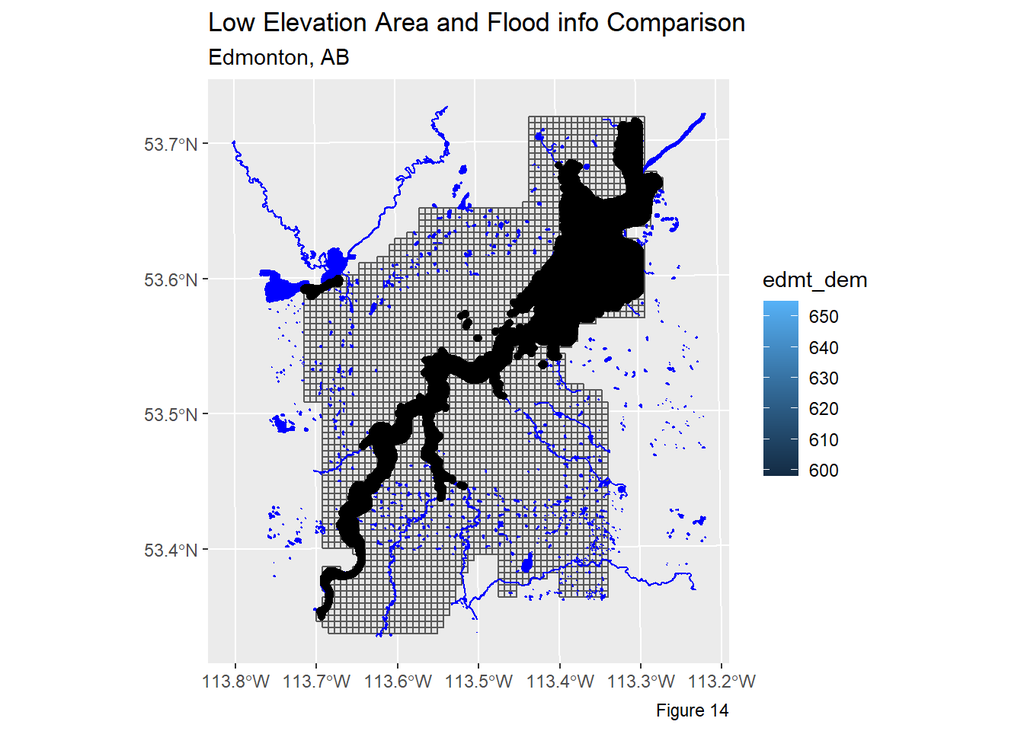

```r
ed_elevationp <-
  rasterToPoints(tif1) %>%
  as.data.frame() %>%
  st_as_sf(coords = c("x", "y"), crs = 3780)

ed_lowland <- ed_elevationp%>%
  filter(edmt_dem < quantile(ed_elevationp$edmt_dem, probs = 0.15))


ed_elevation_net <-
  ed_elevationp %>%
  aggregate(., ed_fishnet, mean)%>%
  mutate(elevation = ifelse(is.na(edmt_dem), mean(na.omit(edmt_dem)), edmt_dem))

ggplot() +
  geom_sf(data=ed_fishnet) +
  geom_sf(data=ed_hydro, color = "blue", fill = "blue") +
  geom_sf(data=ed_lowland, aes(fill=edmt_dem)) +
  labs(title="Low Elevation Area and Flood info Comparison",
       subtitle="Edmonton, AB",
       caption="Figure 14")
```

We look at the slope and the relationship between steep slope and hydromap.

```r
ed_sloper <- raster("C:/Users/mnxan/OneDrive/Documents/CPLN 675/midTermProject_Data/assignment3_Edmonton/edmnt_sloper.tif")
```

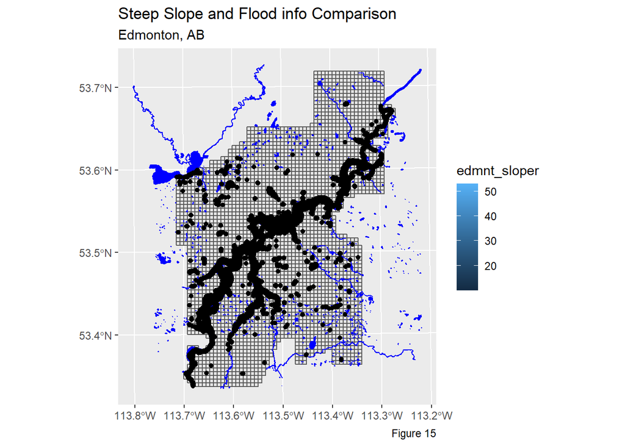

```r
ed_slopep <-
  rasterToPoints(ed_sloper) %>%
  as.data.frame() %>%
  st_as_sf(coords = c("x", "y"), crs = 3780)

ed_steepp <- ed_slopep %>%
  filter(edmnt_sloper > 10)

ed_slopep_net <-
  ed_slopep %>%
  aggregate(., ed_fishnet, mean)%>%
  mutate(sloper = ifelse(is.na(edmnt_sloper), mean(na.omit(edmnt_sloper)), edmnt_sloper))

ed_steep_net <-
  ed_steepp %>%
  mutate(steep =1) %>%
  aggregate(., ed_fishnet, sum) %>%
  mutate(steep = ifelse(is.na(steep), 0, steep))%>%
  dplyr::select(steep)

ggplot() +
  geom_sf(data=ed_fishnet) +
  geom_sf(data=ed_hydro, color = "blue", fill = "blue") +
  geom_sf(data=ed_steepp, aes(fill=edmnt_sloper))+
  labs(title="Steep Slope and Flood info Comparison",
       subtitle="Edmonton, AB",
       caption="Figure 15")
```

Landuse: filter the parks out.

```r
ed_landuse <- st_read("C:/Users/mnxan/OneDrive/Documents/CPLN 675/midTermProject_Data/assignment3_Edmonton/landuse/geo_export_829bdf17-2022-456d-be4a-9fa8190550d9.shp") %>%
  st_transform(crs=3780)

ed_park <-
  ed_landuse %>%
  filter(land_use_d== "Natural Preserve") %>%
  mutate(park =1) %>%
  aggregate(., ed_fishnet, mean) %>%
  mutate(park = ifelse(is.na(park), 0, park))%>%
  dplyr::select(park)
```

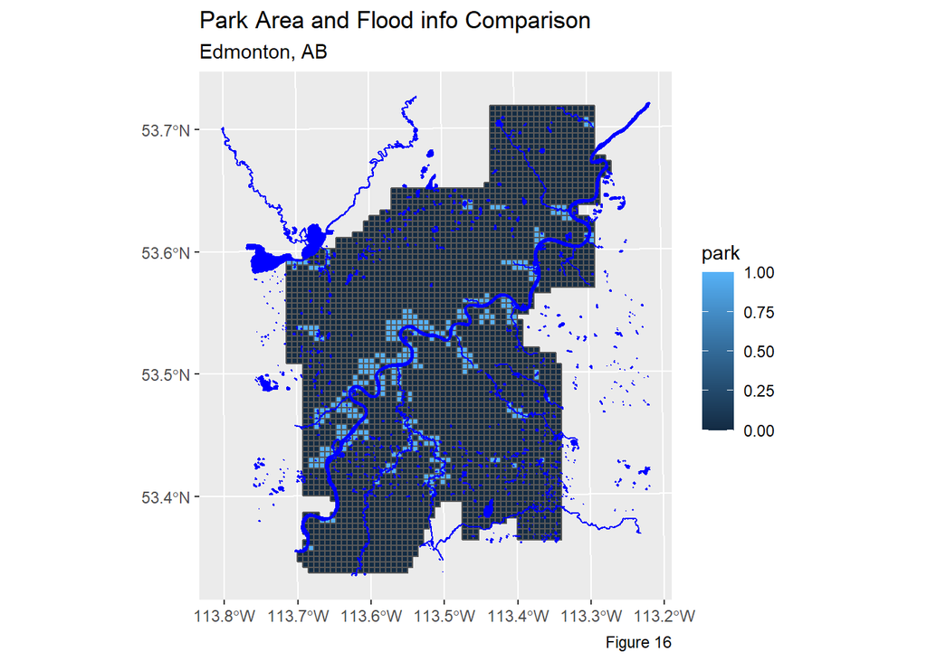

```r
ggplot() +
  geom_sf(data=ed_park, aes(fill=park)) +
  geom_sf(data=ed_hydro, color = "blue", fill = "blue")+
  labs(title="Park Area and Flood info Comparison",
       subtitle="Edmonton, AB",
       caption="Figure 16")
```

And of course, the tree data

```r
ed_tree <- st_read("C:/Users/mnxan/OneDrive/Documents/CPLN 675/midTermProject_Data/assignment3_Edmonton/tree/geo_export_d744ef92-4283-4e41-a7cb-94acbbca425a.shp") %>%
  st_transform(crs=3780)
```

[figure not shown]

Join them to the fishnet

```r
ed_vars_net <-
  cbind(ed_elevation_net, ed_tree_net, ed_slopep_net, ed_steep_net, ed_park)%>%
  mutate(slope=edmnt_sloper)%>%
  dplyr::select(elevation, tree, slope, steep, park,-edmt_dem,)%>%
  mutate(uniqueID = rownames(.))

ed_vars_net$steep.nn =
  nn_function(st_coordinates(st_centroid(ed_vars_net)), st_coordinates(ed_steepp), 3)
ed_vars_net$tree.nn =
  nn_function(st_coordinates(st_centroid(ed_vars_net)), st_coordinates(ed_tree), 3)
ed_vars_net$hydro.nn =
  nn_function(st_coordinates(st_centroid(ed_vars_net)), st_coordinates(st_centroid(ed_hydro)), 3)
ed_river_net <-
  ed_hydro %>%
  dplyr::select() %>%
  mutate(river = as.numeric(1)) %>%
  aggregate(., ed_fishnet, mean) %>%
  mutate(river = ifelse(is.na(river), 0, river))

final2 <-
  ed_vars_net %>%
  mutate(elev = elevation - min(elevation)) %>%
  mutate(stee = steep/max(steep)) %>%
  dplyr::select(-elevation, -steep)
```

### Prediction Results

We apply the previous model into the Edmonton Data

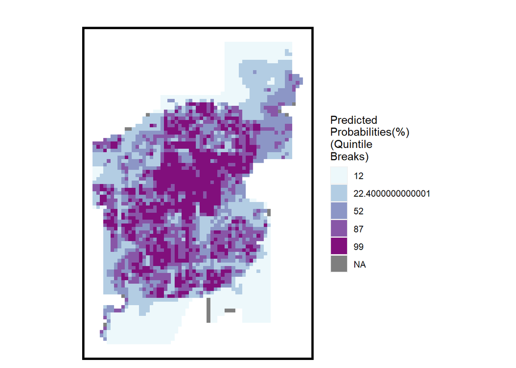

```r
classProbs2 <- predict(finalModel, final2, type="response")

finalflood2 <-
  cbind(final2,classProbs2) %>%
  mutate(allPredictions2 = round(classProbs2 * 100))

ggplot() +
  geom_sf(data=finalflood2, aes(fill=factor(ntile(allPredictions2,5))), colour=NA) +
  scale_fill_manual(values = c("#edf8fb","#b3cde3","#8c96c6","#8856a7","#810f7c"),
                    labels=as.character(quantile(finalflood2$allPredictions2,
                                                 c(0.1,.2,.4,.6,.8),na.rm=T)),
                    name="Predicted\nProbabilities(%)\n(Quintile\nBreaks)") +
  mapTheme() +
  labs(title="")
```

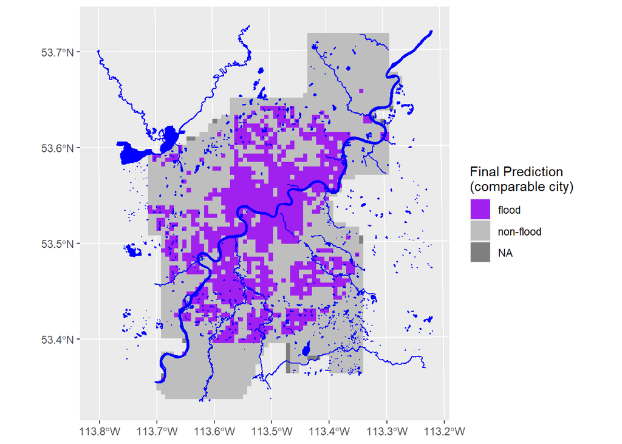

```r
finalpre2 <-
  finalflood2 %>%
  mutate(pre = ifelse(allPredictions2<95,1,0))

ggplot() +
  geom_sf(data=finalpre2, aes(fill=factor(pre)), colour=NA) +
  scale_fill_manual(values = c("purple","grey"),
                    labels=c("flood","non-flood"),
                    name="Final Prediction\n(comparable city)") +
  geom_sf(data=ed_hydro, color = "blue", fill = "blue")
```

```r
  mapTheme()
```

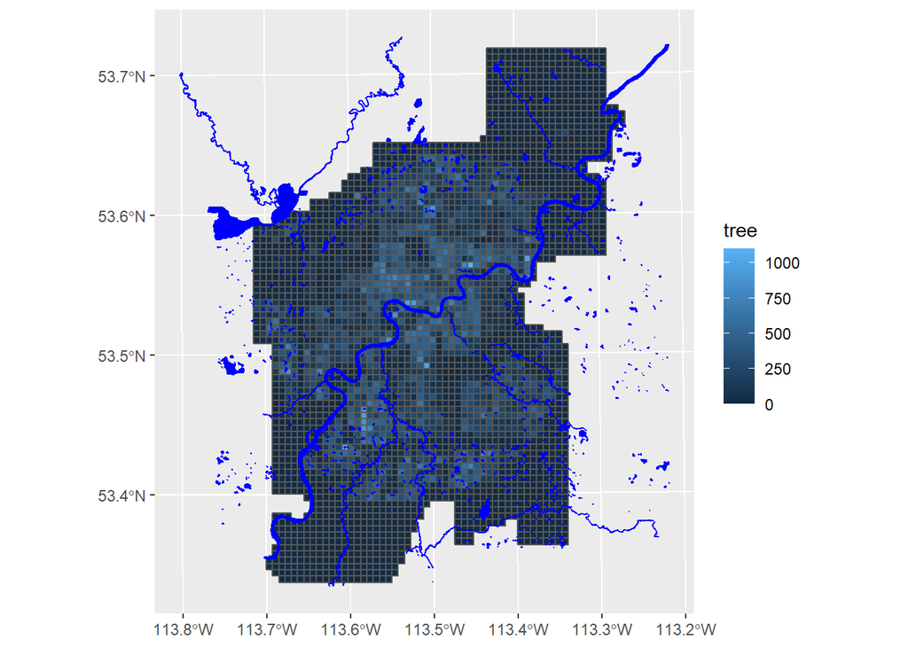

```r
ggplot() +
    geom_sf(data=ed_tree_net, aes(fill=tree)) +
    geom_sf(data=ed_hydro, color = "blue", fill = "blue")
```

### Reflection

For Calgary’s prediction of high-risk flood areas, the dependent variables we consider are slopes, hydrology, elevation, natural preserved land, trees. The prediction map calculated from these dependent variables agrees with previous flood coverage areas. However, for the Edmonton area, the high-risk flood areas on the predicted map calculated by the same dependent variable are primarily affected by the location of urban trees, or there is an inevitable error.

Our prediction is based on integrating existing relevant resources in the city. We comprehensively consider the largest influencing factors of flood flow under extreme weather: elevation and slopes. We also verified the reliability of our prediction model by fitting the ROC curve (0.8737), which proves that this is a more reliable prediction model.

For our prediction model for Edmonton, we felt that the location of trees too influenced the map results. Therefore, in the next step, we need to make some adjustments to this model, remove the dependent variable of tree location or reduce the influence of trees on the entire prediction model.